# Lab Day 1

Intorduction to R

Heath Blackmon

02 January 2018

## R is a high level language

This means that many actions are completed using functions that have intuitive names for instance to find the mean of some numbers you use the `mean` function.

## The very basic

You can use R like a calculator

```r
1 + 1
```

```
## [1] 2
```

```r
3 * 3
```

```
## [1] 9
```

```r
sqrt(81)
```

```
## [1] 9
```

```r
log(.5)
```

```
## [1] -0.6931472
```

```r
exp(-.6931472)
```

```
## [1] 0.5
```

R is case sensitive

```
Log(.4)
Error in Log(0.4) : could not find function "Log"
```

## Logic

R contains all of the typical logical operators and will return TRUE and FALSE

```r
# single comparisons
4 > 5
```

```
## [1] FALSE
```

```r
4 < 5
```

```
## [1] TRUE
```

```r
4 <= 5
```

```
## [1] TRUE
```

```r
4 == 5
```

```
## [1] FALSE
```

```r
# and or
1 == 1 & 1 < 4
```

```
## [1] TRUE
```

```r
1 == 1 & 1 > 4
```

```
## [1] FALSE
```

```r
1 == 1 | 1 < 4
```

```
## [1] TRUE
```

```r
1 == 1 | 1 > 4
```

```
## [1] TRUE
```

```r
# multiple comparisons
4 > c(1, 3, 5, 7, 9)
```

```
## [1]  TRUE  TRUE FALSE FALSE FALSE
```

```r
# recycling
c(1,6) < c(1, 6, 2, 7)
```

```
## [1] FALSE FALSE  TRUE  TRUE
```

```r
# TRUE and FALSE have values of 1 and 0 respectively
sum(1 == 1)
```

```
## [1] 1
```

```r
sum(1 > 5)
```

```
## [1] 0
```

```r
# TRUE is the same as T
# FALSE is the same as F
sum(c(T,T,T,F,T))
```

```
## [1] 4
```

```r
sum(c(TRUE,TRUE,TRUE,FALSE,TRUE))
```

```
## [1] 4
```

## Control Structures

R contains standard control structures like if, for, and while as well as some special ones like the apply family of functions. We won’t use these a whole lot in this class so we will just show the basic for loop and if statement.

```r
for(i in 1:4){
  if(i == 1) cat("I tried this", i, "time\n")
  if(i >  1) cat("I tried this", i, "times\n")
}
```

```
## I tried this 1 time
## I tried this 2 times
## I tried this 3 times
## I tried this 4 times
```

## Variables

We can use variables by using the assignment operator “<-” the names of variables should be lowercase and should suggest what they contain.

```r
false.pos <- 84
false.pos
```

```
## [1] 84
```

```r
total.tests <- 1568
fp.rate <- false.pos / total.tests
fp.rate
```

```
## [1] 0.05357143
```

## Data structures

The basic data structure in R is a vector. A vector is a sequence of data items. Each item in a vector must be of the same type (numeric, character, logical, etc). R also uses matrices and data frames. These are basically tables. From the perspective of R you can think of a matrix as a collection vectors of the same length with the same type of data combined as the columns of the matrix. A data frame is more flexible in that each column can have a different type of data (character, logical, etc). Lets look at how we build some of these items in R. The most flexible type of data structure in R is the list. You can think of the list as a special type of vector but one where every element can contain just about anything that you want. For instance you could have a list where the first element was a numeric vector with 300 numeric values, the second element of the list could be a matrix, and the third could be another list with three character vector inside of it.

```r
# to make an empty vector
v <- vector()

# or a vector with numbers already in it
v <- c(1, 13, 5, 2)

# to make a matrix
m <- matrix(0, 3, 4)
# with the matrix function the 3 arguments are
# 1) the data - I put a zero here so it filled the whole matrix with zeros
# 2) the number of rows
# 3) the number of columns

# lets look at that matrix
m
```

```
##      [,1] [,2] [,3] [,4]
## [1,]    0    0    0    0
## [2,]    0    0    0    0
## [3,]    0    0    0    0
```

```r
# lets try filling it with something
m <- matrix(1:12, 3, 4)
m
```

```
##      [,1] [,2] [,3] [,4]
## [1,]    1    4    7   10
## [2,]    2    5    8   11
## [3,]    3    6    9   12
```

```r
# as we can see it fills this matrix by columns
# we can change this with the byrow command
m <- matrix(1:12, 3, 4, byrow=T)
m
```

```
##      [,1] [,2] [,3] [,4]
## [1,]    1    2    3    4
## [2,]    5    6    7    8
## [3,]    9   10   11   12
```

```r
# lets make a dataframe
# first we will make a character vector
cv <- c("kendrick","taylor","cardi","liluzi")
df <- data.frame(cv, v)

# lets look at the versitility of lists
biglist <- list(df, cv, m, v)
```

## Factors

If you will remember R was built as a language for statistical analysis. To this end there are many built in behaviors that are geared toward statistics. The ubiquity of factors is one of these behaviors. When we do experiments we often have different treatment conditions (medication vs placebo or fertilized vs unfertilized). R knows this and so when we read character vectors R will often assume that these characters are the names for the different conditions (or factors) in our experiment.

```
# when reading a table of data we can avoid this
# by setting the as.is argument to TRUE
data <- read.csv("data", as.is=T)
```

## Distributions

For each type of distribution (normal, exponential, uniform, etc) R has a family of functions formed by using the prefixes d, p, q, r and the abbreviated name for the function. For instance for the normal distribution these function are dnorm, pnorm, qnorm, and rnorm.

### pnorm

`pnorm` is used to calculate the probability that a value less than or equal to q is drawn from a normal distribution with the specified mean and standard deviation. As an example lets look at the probability that a value of 1.96 is drawn from a normal distribution with a mean of zero and a standard deviation of one. From lecture you should remember that the probability should be about 2.5%.

```r
pnorm(q = 1.96, mean = 0, sd = 1, lower.tail = FALSE)
```

```
## [1] 0.0249979
```

We had to include `lower.tail = FALSE` because we are looking at the upper end of the distribution rather than the lower end of the distribution.

### qnorm

`qnorm` is basically the inverse of `pnorm`. With pnorm we supply a value and we get a probability. with qnorm we provide a quantile (or probability) and ask for the value that is associated with that value. For instance suppose that human body temperatures are normally distributed with a mean of 37 and a standard deviation of 0.25. Lets determine what temperature you would expect to see in those 5% of people with the highest temperature.

```r
qnorm(0.95, mean=37, sd=.25)
```

```
## [1] 37.41121
```

So 5% of people would be expected to have temperatures equal to or higher than this even if they are healthy.

### dnorm

`dnrom` provides the value of the probability density function at a specified value given a mean and standard deviation.

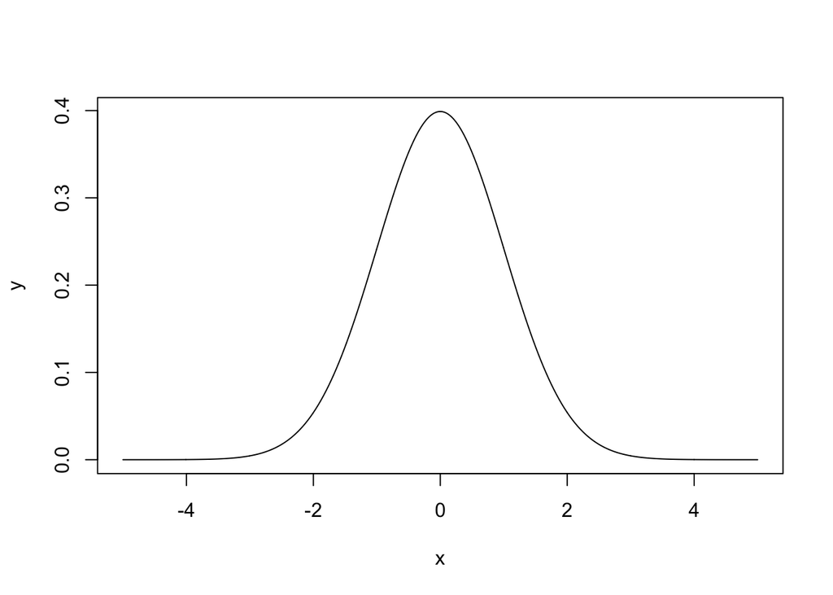

```r
x <- seq(from = -5, to = 5, length.out=1000)
y <- dnorm(x, mean = 0, sd = 1)
plot(y ~ x, type="l")
```

### rnorm

`rnorm` the functions with “r” prefixes simply provide random draws from the distribution.

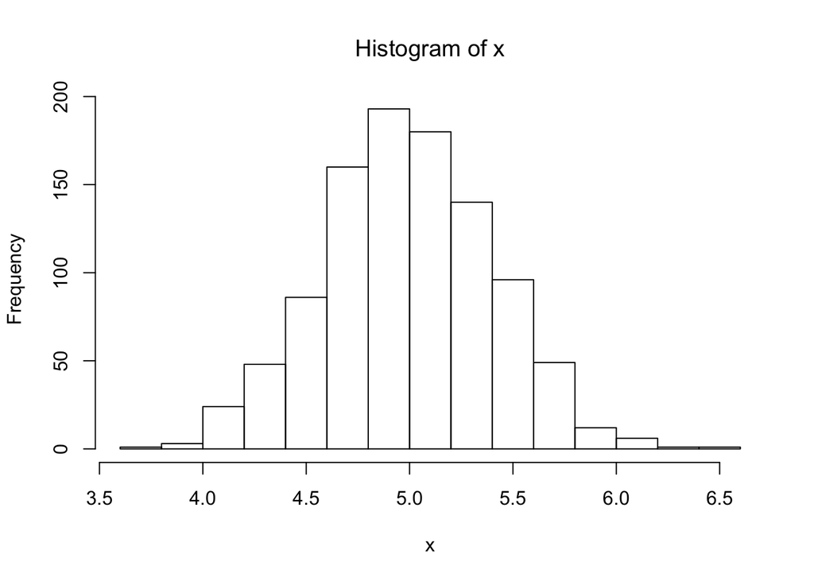

```r
x <- rnorm(n = 1000, mean = 5, sd = .4)
hist(x)
```

Although we focused on the normal distribution function similar functions are also available for other distributions like the beta, binomial, cauchy, chi-square, exponential, gamma, geometric, logistic, log normal, poisson, student t, uniform, and MORE!

## Simulation

Sometimes you will have an experiment where your results dont follow a clear expected distribution. One way we can test for significance in these situations is to simulate observations under our null model and then compare our observation to that simulated distribution. Lets use an example from sexual selection. Some beetles fight with each other to decide who gets to mate. You are interested in finding out whether some of your beetles have higher fitness and win more fights. Lets imagine an experiment where you take 10 beetles and let each beetle fight 6 times. Using the `rbinom` function calculate the probability that at least one of your beetles would win all 6 fights even if the beetles have equal fitness with regard to fighting.

```r
# setting a seed just forces us all to get the same random number draws
set.seed(1)

# here we create an empty vector to store the number of winners
unbeaten <- vector()

# this loop lets us simulate our experiment 1000 times
for(i in 1:1000){
  unbeaten[i] <- sum(rbinom(n = 10, size = 6, prob = 0.5) == 6)
  # the arguments to rbinom capture our experiment
}

# this is what we were really after how often we see the result of
# our experiment just by chance alone
sum(unbeaten>=1)/length(unbeaten)
```

```
## [1] 0.145
```

```r
# this next bit will just show how you
# could make a nice graph to display the result
range(unbeaten)
```

```
## [1] 0 2
```

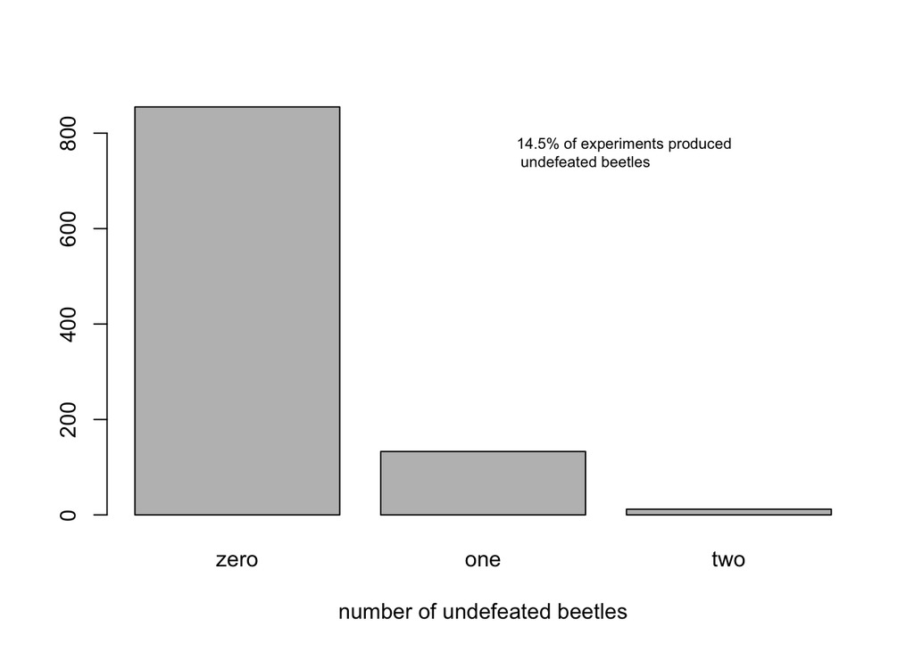

```r
# here we just create a vector with the experiments that
# containe 0, 1, or 2 undefeated beetles
x <- c(sum(unbeaten == 0), sum(unbeaten == 1), sum(unbeaten == 2))

# now we make a barplot
barplot(x,
        names = c("zero", "one", "two"),
        xlab = "number of undefeated beetles")

# lets add some interpretive text to that
text(x = 2,
     y = 750,
     labels = paste(sum(x[2:3])/sum(x)*100,
                    "% of experiments produced\n undefeated beetles", sep = ""),
     pos=4, cex=.7)
```

## Data in/out

To start with lets use some data that is included when you install R

```r
data(iris)
head(iris)
```

```
##   Sepal.Length Sepal.Width Petal.Length Petal.Width Species
## 1          5.1         3.5          1.4         0.2  setosa
## 2          4.9         3.0          1.4         0.2  setosa
## 3          4.7         3.2          1.3         0.2  setosa
## 4          4.6         3.1          1.5         0.2  setosa
## 5          5.0         3.6          1.4         0.2  setosa
## 6          5.4         3.9          1.7         0.4  setosa
```

This is a morphological dataset from a study of 3 species of iris occurring on a peninsula of Quebec. Lets set our working directory and then save this as a CSV file.

```r
# on my computer this describes the location of my desktop this may vary for you
# in RStudio you can use the file tab of the lower right panel to set your working directory
setwd("~/Desktop")
write.csv(iris, file="iris.csv", row.names=FALSE)
```

If we don’t use the row.names=FALSE R will add the row names to the file being written. In this case that would have just created a column that had values 1 to 150.

Reading in a file is just as simple.

```r
setwd("~/Desktop")
iris.dat <- read.csv("iris.csv")
```

## Accessing and Subsetting

There are two basic ways of accessing portions of a dataset. One is using braces “[ ]” to tell R what elements or cells we are interested in. If we are working with matrices we can also use column names.

```r
x <- 1:10
# in the case of a vector we can specify certain elements that we want
x[1:5]
```

```
## [1] 1 2 3 4 5
```

```r
x[c(1,5,10)]
```

```
## [1]  1  5 10
```

```r
# we can also use a vector of TRUE and FALSE values to select the elements we want
pick <- c(TRUE, FALSE, TRUE, FALSE, TRUE, FALSE, TRUE, FALSE, TRUE, FALSE)
x[pick]
```

```
## [1] 1 3 5 7 9
```

```r
# with a matrix we have to give both the rows and columns that we want
m <- matrix(1:9, 3, 3, byrow = T)
m
```

```
##      [,1] [,2] [,3]
## [1,]    1    2    3
## [2,]    4    5    6
## [3,]    7    8    9
```

```r
m[1, 3]
```

```
## [1] 3
```

```r
# to get all rows we leave the first value empty
m[, 3]
```

```
## [1] 3 6 9
```

```r
# to get all columns we leave the second value empty
m[1, ]
```

```
## [1] 1 2 3
```

```r
# we can also supply a range
m[1:2, 3]
```

```
## [1] 3 6
```

```r
# we can also use a logical vector as above
pick <- c(T, F, T)
m[pick, 3]
```

```
## [1] 3 9
```

```r
# lists work similar to vectors but use double braces
exlist <- list(m, x, pick)
exlist[[3]]
```

```
## [1]  TRUE FALSE  TRUE
```

## Plotting in R

One of the great advantages of R is the ease of creating a variety of plots. Today we will briefly look at a few of the common types of plots

### histogram

A histogram is one of the most basic types of plots and should probably be used on any data that you collect just to get an idea of how your data is distributed.

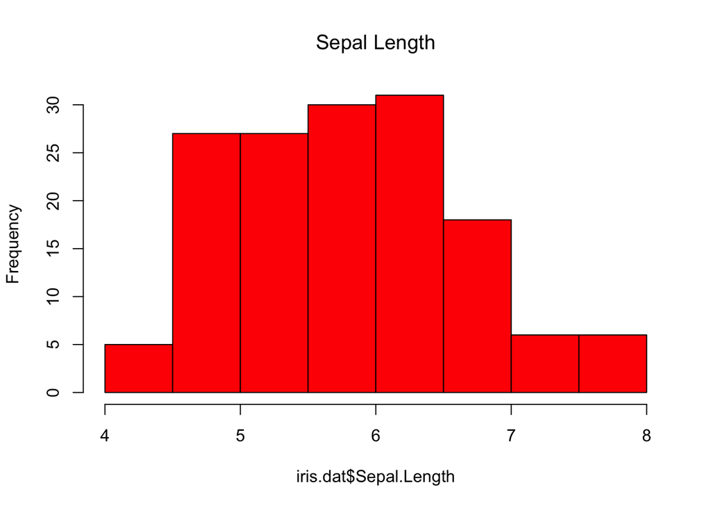

```r
hist(iris.dat$Sepal.Length,
     main = "Sepal Length",
     col="red")
```

### XY scatter

When you have two continuous variables an XY scatter is probably going to be your starting point.

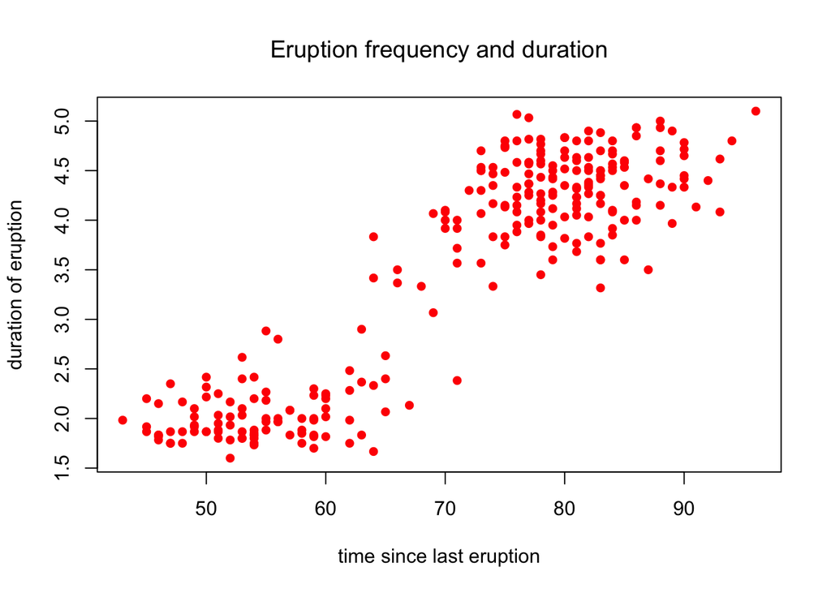

```r
#lets pull up the old faithful data
data(faithful)
# remember keep your explanatory variable on the bottom
plot(faithful$eruptions ~ faithful$waiting,
     main = "Eruption frequency and duration",
     xlab = "time since last eruption",
     ylab = "duration of eruption",
     col  = "red",
     pch  = 16)
```

### box plot

When you want to compare a continuous variable across different factors or states the boxplot provides a basic starting point

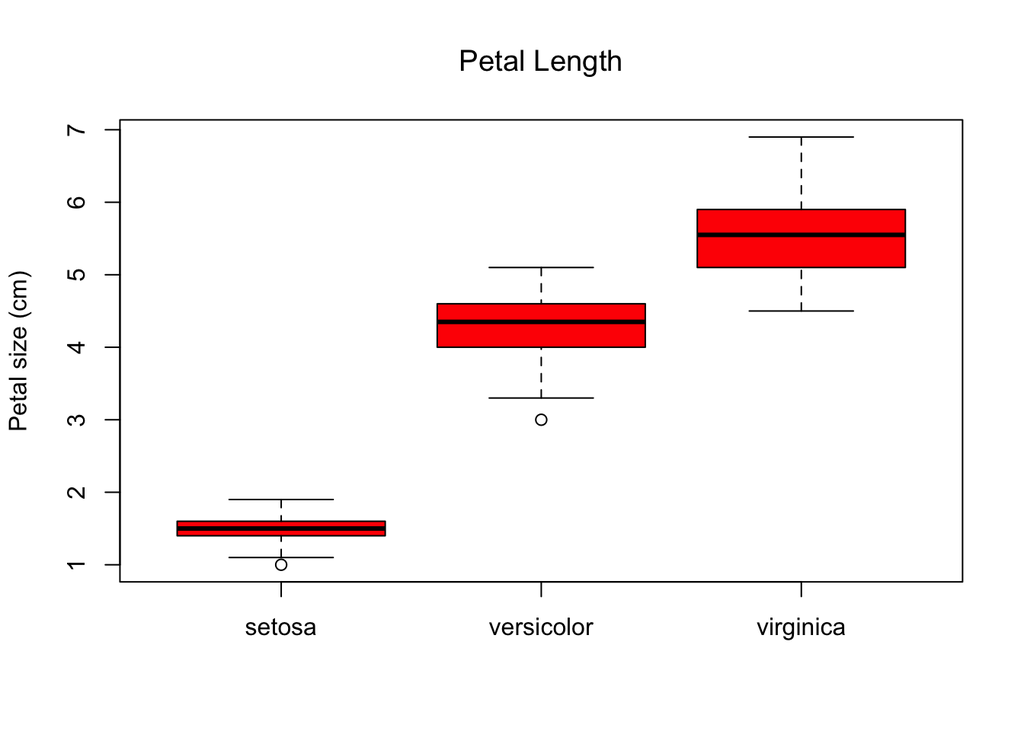

```r
# lets compare petal length in the iris data
boxplot(iris.dat$Petal.Length ~ iris.dat$Species,
     main = "Petal Length",
     ylab = "Petal size (cm)",
     col  = "red")
```

### strip chart

Sometimes we would like to show our data even more directly than we can with the boxplot. A good choice for this is the strip chart.

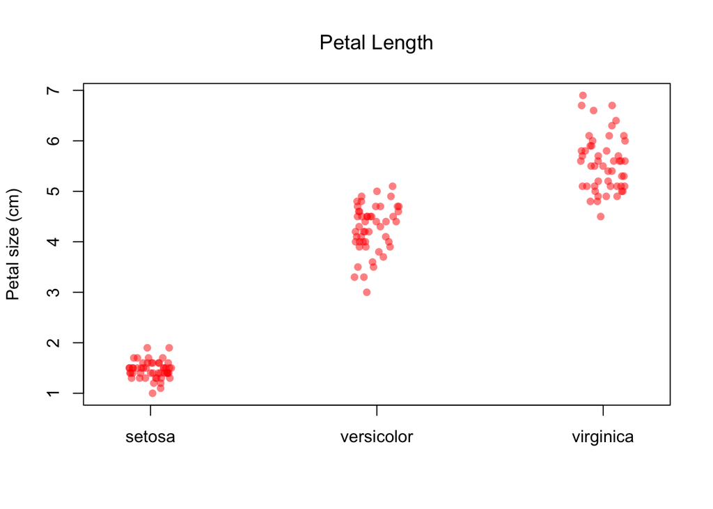

```r
# lets compare petal length in the iris data
stripchart(iris.dat$Petal.Length ~ iris.dat$Species,
     main = "Petal Length",
     ylab = "Petal size (cm)",
     col  = rgb(1,0,0,.5),
     vertical = T,
     method = "jitter",
     pch=16)
```

### bar plot

Barplots are a good option when we want to show discrete outcomes for multiple classes. Lets use data from the ship wreck of the Titanic .

```r
data("Titanic")
# there is a lot of data that we don't care about here so lets simplify
Titanic <- apply(Titanic, c(2, 4), sum)
Titanic
```

```
##         Survived
## Sex        No Yes
##   Male   1364 367
##   Female  126 344
```

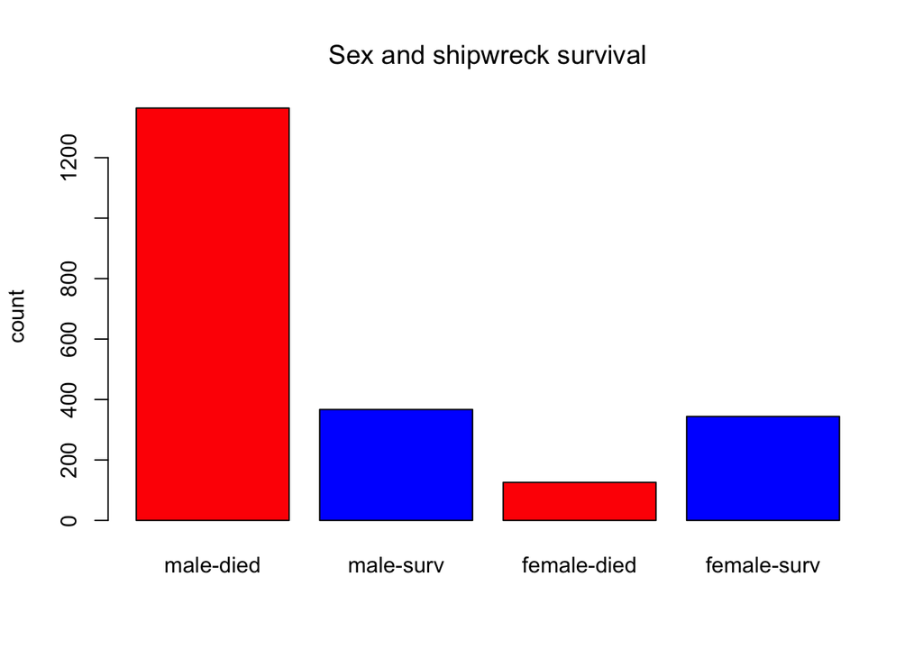

```r
# now we will reformat as a vector
titanic <- c(Titanic[1,1:2], Titanic[2,1:2])

# now lets name the elements
names(titanic) <- c("male-died", "male-surv", "female-died", "female-surv")
barplot(titanic,
        main = "Sex and shipwreck survival",
        ylab = "count",
        col  = c("red", "blue"),
        pch=16)
```

### mosaic plot

Another option for visualizing this same data is the mosaic plot

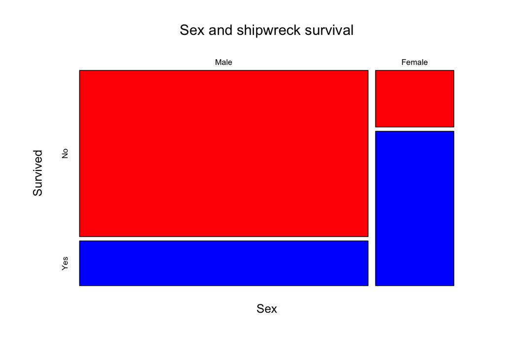

```r
mosaicplot(Titanic,
           col=c("red","blue"),
           main = "Sex and shipwreck survival")
```

### heatmap

When we have 3 continuous variables or one continuous variable across many levels of two discrete states we often will use heat maps. There are a variety of R function that we can use for this but `image` and `contour` are good places to start.

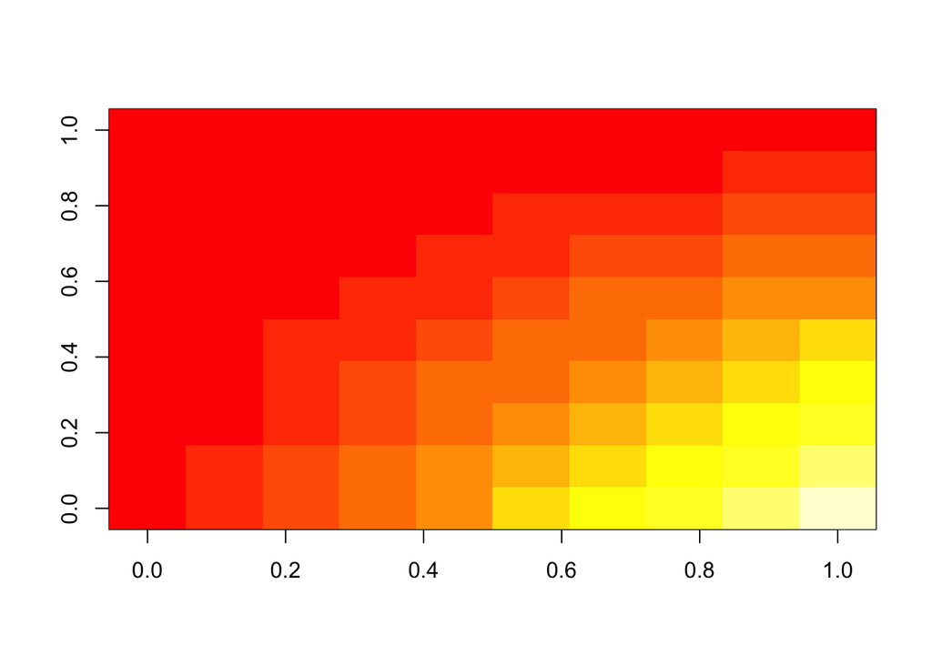

```r
# we will simulate a little data
x <- matrix(,10,10)
for(i in 1:10){
  x[i, ] <- i*1:10
}

# here i have used the t function to rotate the matrix and the [10:1, ] argument to
# make the plot layout match the way we normally look at tables
image(t(x[10:1,]))
```

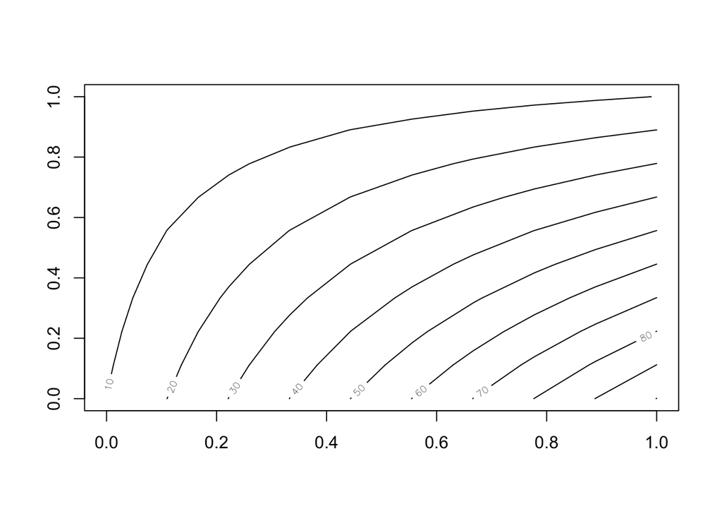

```r
contour(t(x[10:1,]))
```